# Semester 4 Coding Portfolio Part 7: Dimensionality Reduction

This notebook covers the following topics:

- Feature selection
- PCA
- LDA
- t-SNE

This notebook is expected to take around 20 hours to complete:

- 4 hours for the formative part
- 6 hours of self-study on the topics covered by this notebook
- 10 hours for the summative part of this notebook

Like all notebooks in this portfolio, it is split into two sections:

- Formative
- Summative

**Formative section**  
Simply complete the given functions such that they pass the automated tests. This part is graded Pass/Fail; you must get 100% correct! You can submit your notebook through Canvas as often as you like. Make sure to start doing so early to insure that your code passes all tests! You may ask for help from fellow students and TAs on this section, and solutions might be provided later on.

**Summative section**  
In this section, you are asked to do original work with little guidance, based on the skills you learned in the formative part (as well as lectures and workshops). This section is graded not just on passing automated tests, but also on quality, originality, and effort (see assessment criteria in the assignment description).

```python
# TODO: Please enter your student number here
STUDENT_NUMBER = 14806762
```

# Formative Section

Please do not add additional cells to this section, and do not delete given code. Simply fill out the code or answer questions in the given cells.

```python
# Imports
import math
import time

import numpy as np
import pandas as pd
import scipy.stats as stats
import matplotlib.pyplot as plt
import seaborn as sns
from sklearn.model_selection import train_test_split
```

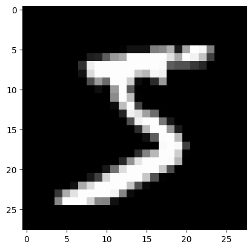

```python
# We will use the MNIST datset again
from sklearn.datasets import fetch_openml
X, y = fetch_openml('mnist_784', return_X_y=True)
X = np.array(X)
y = np.array(y)
X_train, X_test, y_train, y_test = train_test_split(X, y, test_size=0.1, random_state=42)
test_img = X[0].reshape(28,28)
plt.imshow(test_img, cmap='gray')
```

## Part 1: Feature selection

In the last notebook, we trained a neural network classifier on the MNIST dataset to determine what number it displayed. Depending on how you implemented you model, it probably took quite a while to train even on small subsets. Let's recreate our neural network, or multi-layer perceptron from the previous notebook; to save you from copying over all your code, we'll use sklearns built-in method here:

```python
from sklearn.neural_network import MLPClassifier

X_subset = X_train[:10000,:]
y_subset = y_train[:10000]

clf = MLPClassifier(solver='adam', alpha=1e-5, hidden_layer_sizes=(16, 16), random_state=42)
start = time.time()
clf.fit(X_subset, y_subset)
print(f'It took {time.time() - start:.3f} seconds to train this model')
print(f'Accuracy: {clf.score(X_test, y_test):.3f}')
```

```
It took 9.011 seconds to train this model
Accuracy: 0.870
```

On my machine, this takes about 5 seconds to train the classifier on just 10000 samples from the dataset. Of course we don't want to waste all that data we have, but we also don't want a model to take forever to converge. So what can we do to make our model faster? Well, if you look at the sample image we drew from the MNIST data, you can imagine that some of those black pixels on the edges probably aren't nearly as important to figuring out that this is a 5 then more central pixels are. Right now we are training our perceptron on 784 dimensions. How about we reduce the dimensionality a bit and see if we hurt the accuracy all that much.

The easiest way to reduce the dimensionality of your dataset is to simply select a subset of all available features. We might decide, for example, after looking at this single example image above, that the 4 outermost pixels on any side probably don't matter all that much in determining the number.

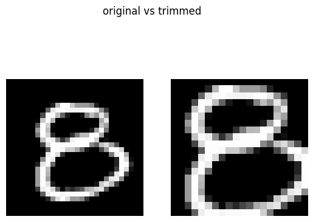

```python
def trim_image_data(data):
    # TODO 1: Reshape X_subset, X_test, and t_test into 28x28 pixel images, then cuts them down to 20x20 pixel images by removing 4 pixels of each side. Then, flatten the data again to have shape (:,400)

    #. Your solution here ...
    # Reshape into 28x28 images
    data = data.reshape(-1, 28, 28)

    # Remove 4 pixels from each side (keep only the central 20x20)
    data = data[:, 4:24, 4:24]

    # Flatten back to shape (:, 400)
    data = data.reshape(data.shape[0], -1)

    return data

# Run our function on X_subset
X_subset_trimmed = trim_image_data(X_subset)

# Let's see how our new input data looks
fig, (ax1, ax2) = plt.subplots(1,2)
ax1.imshow(X_subset[0].reshape(28,28), cmap='gray')
ax2.imshow(X_subset_trimmed[0].reshape(20,20), cmap='gray')
fig.suptitle('original vs trimmed')
ax1.axis('off')
ax2.axis('off')
plt.show()
```

Let's see whether this makes our model run any faster, and whether we lose any accuracy as a result.

```python
# Let's preprocess out test data with the same function to that our trained model will be able to use it
X_test_trimmed = trim_image_data(X_test)

# Retrain our classifier and test it on similarly trimmed test data
clf = MLPClassifier(solver='adam', alpha=1e-5, hidden_layer_sizes=(16, 16), random_state=42)
start = time.time()
clf.fit(X_subset_trimmed, y_subset)
print(f'It took {time.time() - start:.3f} seconds to train this model')
print(f'Accuracy: {clf.score(X_test_trimmed, y_test):.3f}')
```

```
It took 7.450 seconds to train this model
Accuracy: 0.864
```

# Part 2: PCA

But what if we don't know which features are important and which aren't? What if all features do play some role in determining the class, and we don't want to remove any of them entirely? That's where dimensionality reduction comes in. Let's first try PCA.

```python
from sklearn.decomposition import PCA

# TODO 2: Train PCA on the train set and use it to transform X_subset and X_test

# Train PCA on X_subset
pca = PCA(n_components=60)  # Adjust n_components based on desired dimensionality reduction
pca.fit(X_train)

# Transform both X_subset and X_test using the trained PCA
X_subset_transformed = pca.transform(X_subset)
X_test_transformed = pca.transform(X_test)

#. Your solution here ...

clf = MLPClassifier(solver='adam', alpha=1e-5, hidden_layer_sizes=(16, 16), random_state=42)
start = time.time()
clf.fit(X_subset_transformed, y_subset)
print(f'It took {time.time() - start:.3f} seconds to train this model')
print(f'Accuracy: {clf.score(X_test_transformed, y_test):.3f}')
```

```
It took 1.958 seconds to train this model
Accuracy: 0.906
```

Your model will have gotten faster, but potentially less accurate. If you find a sweetspot, however, your model might actually get more accurate despite the reduction in input data, as you make the perceptron's job easier with nicely preprocessed data. Try playing around with the number of components to see whether you can find a nice balance between speed and accuracy.  
Note that in a real setting, we would need to split our dataset 3 ways: Train, test, and evaluate. Since we are playing with hyperparameters to find a good accuracy score, the test set really is just another train set if you consider yourself a learning automaton who simply optimizes problems fed to you by your lecturer (as you should). We would then need to leave out a final evaluation set from the data to evaluate your final chosen model. ALternatively, we could do things like cross-validation. But we don't care about things like overfitting today, so we'll skip this step.

Finally, have a look whether using PCA allows you to train a classifier on the entire X_train set without taking much longer than the original model:

```python
# TODO 3: Transform the entire train set
X_train_transformed = pca.fit_transform(X_train)

#. Your solution here ...

clf = MLPClassifier(solver='adam', alpha=1e-5, hidden_layer_sizes=(16, 16), random_state=42)
start = time.time()
clf.fit(X_train_transformed, y_train)
print(f'It took {time.time() - start:.3f} seconds to train this model')
print(f'Accuracy: {clf.score(X_test_transformed, y_test):.3f}')
```

```
It took 7.421 seconds to train this model
Accuracy: 0.947
```

Just to get some intuition about what we did to our data, let's invert the transform for our first datapoint to see how much information we have lost through dimensionality reduction.

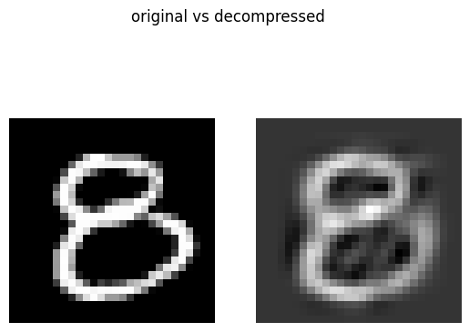

```python
X_decompressed = pca.inverse_transform(X_subset_transformed[0])
fig, (ax1, ax2) = plt.subplots(1,2)
ax1.imshow(X_subset[0].reshape(28,28), cmap='gray')
ax2.imshow(X_decompressed.reshape(28, 28), cmap='gray')
fig.suptitle('original vs decompressed')
ax1.axis('off')
ax2.axis('off')
plt.show()
```

Depending on your chosen parameters for PCA, the number may be barely recognizable to you. Nevertheless, our perceptron still performs well above chance even with a severly compressed dataset.  
Note how we did not "lose" any pixels, since we did not select features, but reduced their dimensionality. While feature selection would have entirely removed information about certain pixels we choose to ignore, dimensionality reduction instead compressed the data, maintaining partial information for all pixels but losing the ability to perfectly recreate the image due to information loss.

Another advantage of dimensionality reduction is that we can visualize high-dimensional data in the two or three dimensions we can perceive. Let's see what the MNIST dataset looks like when plotted after applying PCA.

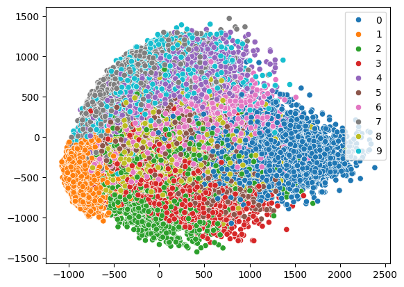

```python
# TODO 4: Use PCA to reduce the MNIST data to 2 dimensions, then plot the transformed train set

# Use PCA to reduce the MNIST data to 2 dimensions
pca_2d = PCA(n_components=2)
pca.fit(X_train)
X_train_transformed = pca.transform(X_train)

#. Your solution here ...

sns.scatterplot(x=X_train_transformed[:,0], y=X_train_transformed[:,1], hue=y_train, hue_order=['0','1','2','3','4','5','6','7','8','9']);
```

When visualizing the data, we'd like to clearly see the structures found within. In this case, that's that there are 10 seperate digits, which should probably show up as 10 seperate clusters. We might also want to see some numbers being more similar to others, such as the numbers 1 and 7 sharing some visual features, whereas 1 and 8 are quite dissimilar. Although we can see some hints of these two facts in this plot, it certainly isn't very clear. PCA perhaps is not the best suited for visualizing this dataset. From the large amout of overlap between classes in this plot we can also see that 2 components are not enough to be able to classify between digits, but that's not really an issue here, since we of course wouldn't use PCA to reduce the dataset to such an extreme for any reason other than vizualiation.

## Part 3: LDA

You may have noticed that PCA did not take the label we are trying to predict into account. It simply tried to restructure the data as well as it could, totally oblivious as to what we might use that data for later. But we do know what we are trying to do, which is to predict which handwritten digit is contained in an image. So let's use a model which takes this into account, such as Linear Discriminant Analysis (LDA), not to be confused with the NLP method Latent Dirichlet Allocation (also LDA) which you used last semester.

```python
from sklearn.discriminant_analysis import LinearDiscriminantAnalysis

# TODO 5: Train LDA on the train set and use it to transform X_subset and X_test

# Train LDA on the train set
lda = LinearDiscriminantAnalysis(n_components=9)
lda.fit(X_train, y_train)

X_subset_transformed = lda.transform(X_subset)
X_test_transformed = lda.transform(X_test)

#. Your solution here ...

clf = MLPClassifier(solver='adam', alpha=1e-5, hidden_layer_sizes=(16, 16), random_state=42)
start = time.time()
clf.fit(X_subset_transformed, y_subset)
print(f'It took {time.time() - start:.3f} seconds to train this model')
print(f'Accuracy: {clf.score(X_test_transformed, y_test):.3f}')
```

```
It took 1.670 seconds to train this model
Accuracy: 0.897
```

To see what we have done to our data, transform a sample and then transform it back into a 28x28 pixel image to see what information was lost, like we did for PCA above.  
Unfortunately sklearn's LDA implementation doesn't have a built-in way to inverse transform, because it doesn't make sense to do so with LDA.  
But because I want you do see what LDA does to the data, you'll have to figure out a way to do it anyway. Google and Stackoverflow are your friends.

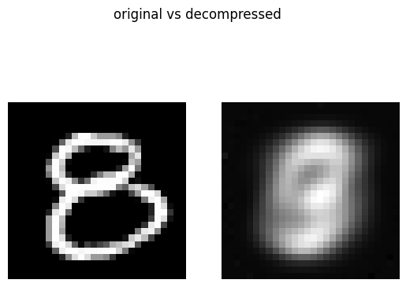

```python
# TODO 6: Plot a side-by-side comparison between an original image and a decompressed image

# Get the projection matrix (discriminant vector)
W = lda.scalings_ # shape is (n_features, n_components)

# Calculate the pseudo-inverse of the projection matrix
W_pinv = np.linalg.pinv(W) # shape is (n_components, n_features)

X_decompressed = np.dot(X_subset_transformed[0], W_pinv) + lda.xbar_

#. Your solution here ...

fig, (ax1, ax2) = plt.subplots(1,2)
ax1.imshow(X_subset[0].reshape(28,28), cmap='gray')
ax2.imshow(X_decompressed.reshape(28, 28), cmap='gray')
fig.suptitle('original vs decompressed')
ax1.axis('off')
ax2.axis('off')
plt.show()
```

Looks weird right? Try a couple of different samples. The LDA reconstruction will look almost the same to you for every input image. That's because LDA reduced the input data to just 9 dimensions (or less if you told it to)! That's not a whole lot of information left to reconstruct unique images from. And yet, because LDA was supervised with the desired output labels, it managed to find just 9 dimensions which allow us to distinguish fairly accurately between those classes.

Finally, let's see how our dataset looks if we use LDA to reduce it to two dimensions.

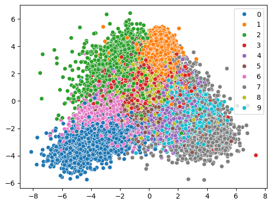

```python
# TODO 7: Use LDA to reduce the MNIST data to 2 dimensions, then plot the transformed train set

lda = LinearDiscriminantAnalysis(n_components=2)
lda.fit(X_train, y_train)
X_train_transformed = lda.transform(X_train)

#. Your solution here ...

sns.scatterplot(x=X_train_transformed[:,0], y=X_train_transformed[:,1], hue=y_train, hue_order=['0','1','2','3','4','5','6','7','8','9']);
```

## Part 4: T-SNE

T-SNE is a dimensionality reduction technique specifically designed for visualization. It is not a useful preprocessing tool for classifiers, because we cannot apply it to new data. Let's use it to visualize then.

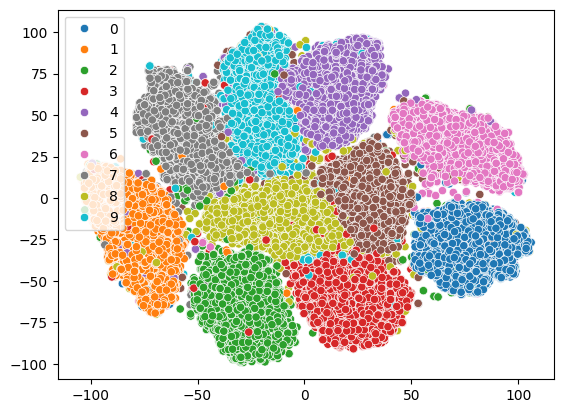

```python
from sklearn.manifold import TSNE

# TODO 8: Use T-SNE to transform X_train into 2 dimensions and plot it

tsne = TSNE(n_components=2, random_state=42)
X_train_transformed = tsne.fit_transform(X_train)

#. Your solution here ...

sns.scatterplot(x=X_train_transformed[:,0], y=X_train_transformed[:,1], hue=y_train, hue_order=['0','1','2','3','4','5','6','7','8','9']);
```

This looks like a pretty impressive arrangement, given that we did not tell TSNE the classes of our data. It learned this mapping entirely unsupervised. That said, this cannot be used to sort new data, so we can neither use this as a classifier itself, not as a preprocessing step for our neural net. We also cannot reconstruct our input data from this, so there is no way to visualize what an 28x28 pixel image embedded as (0,0) in this 2-dimensional space would look like, even though we know it probably represents the digit 8.

Fun fact, unless you changed the init parameter, sklearn's T-SNE implementation actually runs PCA first to make T-SNE not take an absurdly long time to compute pair-wise distances in such a high-dimensional dataset.

# Part 5: Other methods

There are lots of other techniques for reducing dimensionality. Search around a bit and find one more method you think would be useful to apply to the MNIST dataset, then implement it below. Repeat all possible steps from above with this method: If reconstruction is possible, show the digit after decompression to see how much information was lost. Plot the data in 2 dimensions to see how they are clustered. If your method can be run as a preprocessing step, train a neural net with the reduced data.

```python
# TODO 9: Apply your chosen method and use it to reduce the dimensionality of the data. If possible, then run a neural net classifier on the transformed data. If not possible, explain why in comments.

# Here I will use NMF method to reduce the dimensionality of the data.
from sklearn.decomposition import NMF
import numpy as np
import matplotlib.pyplot as plt
import seaborn as sns


nmf = NMF(n_components=10)
nmf.fit(X_train, y_train)

X_subset_transformed = nmf.transform(X_subset)
X_test_transformed = nmf.transform(X_test)

#. Your solution here ...

clf = MLPClassifier(solver='adam', alpha=1e-5, hidden_layer_sizes=(16, 16), random_state=42)
start = time.time()
clf.fit(X_subset_transformed, y_subset)
print(f'It took {time.time() - start:.3f} seconds to train this model')
print(f'Accuracy: {clf.score(X_test_transformed, y_test):.3f}')

#. Your solution here ...
```

```
It took 1.653 seconds to train this model
Accuracy: 0.757
```

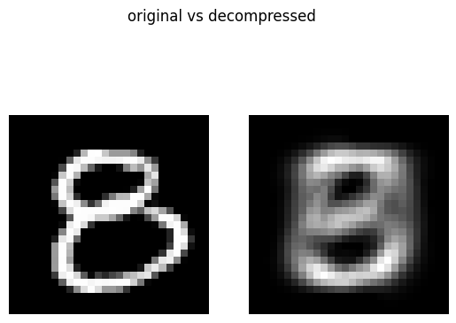

```python
# TODO 10: Plot a side-by-side comparison between an original image and a decompressed image if possible. If not, explain in comments why your method does not allow reconstruction of the data in the original dimensions.

X_decompressed = nmf.inverse_transform(X_subset_transformed)

fig, (ax1, ax2) = plt.subplots(1,2)
ax1.imshow(X_subset[0].reshape(28,28), cmap='gray')
ax2.imshow(X_decompressed[0].reshape(28, 28), cmap='gray')
fig.suptitle('original vs decompressed')
ax1.axis('off')
ax2.axis('off')
plt.show()
```

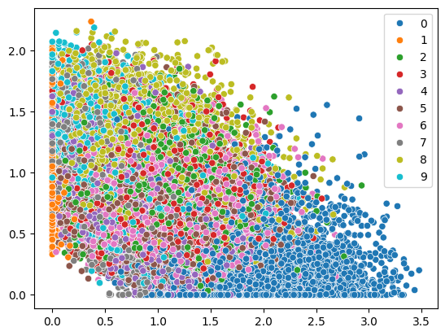

```python
# TODO 11: Use your method to plot the transformed data in 2 dimensions.

nmf = NMF(n_components=2)

X_train_transformed = nmf.fit(X_train,y_train)
X_train_transformed = nmf.transform(X_train)

#. Your solution here ...

sns.scatterplot(x=X_train_transformed[:,0], y=X_train_transformed[:,1], hue=y_train, hue_order=['0','1','2','3','4','5','6','7','8','9'])
```

# SUMMATIVE ASSESSMENT

Now pick a dataset of your choice. Please ensure your dataset is a csv file under 100MB named sem4_portfolio_7_data_custom.csv

Apply any of the relevant models to that dataset, elaborate why you chose the methods you used, and evaluate and visualize your results using lower-dimensional projections. You may use methods not covered in this notebook as long as they reduce the dimensionality of your data.

```python
# Do NOT modify the contents of this cell. Start your customization in the next one!
custom_data_path = "sem4_portfolio_7_data_custom.csv"
custom_df = pd.read_csv(custom_data_path)
```

This dataset includes descriptions of hypothetical samples corresponding to 23 species of gilled mushrooms in the Agaricus and Lepiota Family Mushroom drawn from The Audubon Society Field Guide to North American Mushrooms (1981). Each species is identified as definitely edible, definitely poisonous, or of unknown edibility and not recommended. This latter class was combined with the poisonous one. The Guide clearly states that there is no simple rule for determining the edibility of a mushroom; no rule like "leaflets three, let it be'' for Poisonous Oak and Ivy.

Attribute Information: (classes: edible=e, poisonous=p)

cap-shape: bell=b,conical=c,convex=x,flat=f, knobbed=k,sunken=s

cap-surface: fibrous=f,grooves=g,scaly=y,smooth=s

cap-color: brown=n,buff=b,cinnamon=c,gray=g,green=r,pink=p,purple=u,red=e,white=w,yellow=y

bruises: bruises=t,no=f

odor: almond=a,anise=l,creosote=c,fishy=y,foul=f,musty=m,none=n,pungent=p,spicy=s

gill-attachment: attached=a,descending=d,free=f,notched=n

gill-spacing: close=c,crowded=w,distant=d

gill-size: broad=b,narrow=n

gill-color: black=k,brown=n,buff=b,chocolate=h,gray=g, green=r,orange=o,pink=p,purple=u,red=e,white=w,yellow=y

stalk-shape: enlarging=e,tapering=t

stalk-root: bulbous=b,club=c,cup=u,equal=e,rhizomorphs=z,rooted=r,missing=?

stalk-surface-above-ring: fibrous=f,scaly=y,silky=k,smooth=s

stalk-surface-below-ring: fibrous=f,scaly=y,silky=k,smooth=s

stalk-color-above-ring: brown=n,buff=b,cinnamon=c,gray=g,orange=o,pink=p,red=e,white=w,yellow=y

stalk-color-below-ring: brown=n,buff=b,cinnamon=c,gray=g,orange=o,pink=p,red=e,white=w,yellow=y

veil-type: partial=p,universal=u

veil-color: brown=n,orange=o,white=w,yellow=y

ring-number: none=n,one=o,two=t

ring-type: cobwebby=c,evanescent=e,flaring=f,large=l,none=n,pendant=p,sheathing=s,zone=z

spore-print-color: black=k,brown=n,buff=b,chocolate=h,green=r,orange=o,purple=u,white=w,yellow=y

population: abundant=a,clustered=c,numerous=n,scattered=s,several=v,solitary=y

habitat: grasses=g,leaves=l,meadows=m,paths=p,urban=u,waste=w,woods=d

### Why to use dimensionality reduction for this dataset?

Dimensionality reduction is highly beneficial for this dataset. With 22 features, the dataset likely suffers from the "curse of dimensionality," where the number of dimensions increases the sparsity of the data, potentially leading to overfitting, computational inefficiency, and difficulty in visualization or interpretation.

#### Part_1: Data Exploration and Preprocessing

```python
# Drop missing values
custom_df = custom_df.dropna()

print(custom_df.shape)
print(custom_df.head())
```

```
(8124, 23)
  class cap-shape cap-surface cap-color bruises odor gill-attachment  \
0     p         x           s         n       t    p               f
1     e         x           s         y       t    a               f
2     e         b           s         w       t    l               f
3     p         x           y         w       t    p               f
4     e         x           s         g       f    n               f

  gill-spacing gill-size gill-color  ... stalk-surface-below-ring  \
0            c         n          k  ...                        s
1            c         b          k  ...                        s
2            c         b          n  ...                        s
3            c         n          n  ...                        s
4            w         b          k  ...                        s

  stalk-color-above-ring stalk-color-below-ring veil-type veil-color  \
0                      w                      w         p          w
1                      w                      w         p          w
2                      w                      w         p          w
3                      w                      w         p          w
4                      w                      w         p          w

  ring-number ring-type spore-print-color population habitat
0           o         p                 k          s       u
1           o         p                 n          n       g
2           o         p                 n          n       m
3           o         p                 k          s       u
4           o         e                 n          a       g

[5 rows x 23 columns]
```

```python
# Transform categorical data into binary
mapping = {'e': 0, 'p': 1} #edible=0, poisonous=1

# Create y using the "sex" column
y = custom_df['class'].str.strip().str.lower().map(mapping)

X = custom_df.drop(columns=['class'])

# One-hot code X
X = pd.get_dummies(X, columns=X.columns.tolist(), drop_first=True).astype('float')

# Split train and test datasets
X_train, X_test, y_train, y_test = train_test_split(X, y, test_size=0.2, random_state=42)
```

#### Part_2: Split dataset

```python
from sklearn.neural_network import MLPClassifier

X_subset = X_train[:2000]
y_subset = y_train[:2000]

clf = MLPClassifier(solver='adam', alpha=1, hidden_layer_sizes=(1, 1), random_state=42)
start = time.time()
clf.fit(X_subset, y_subset)
print(f'It took {time.time() - start:.3f} seconds to train this model')
print(f'Accuracy: {clf.score(X_test, y_test):.3f}')
```

```
It took 0.586 seconds to train this model
Accuracy: 0.519
```

#### Part_3: Reducing dimensionality with PCA

PCA is chosen for dimensionality reduction because it efficiently transforms data into a lower-dimensional space while maximizing variance retention through orthogonal principal components. It simplifies data by removing correlations between features, reduces noise by discarding low-variance components, and improves computational efficiency for machine learning models.

```python
from sklearn.decomposition import PCA

# Train PCA on X_subset
pca = PCA(n_components=10)  # Adjust n_components based on desired dimensionality reduction
pca.fit(X_subset)

# Transform both X_subset and X_test using the trained PCA
X_subset_transformed = pca.transform(X_subset)
X_test_transformed = pca.transform(X_test)

clf = MLPClassifier(solver='adam', alpha=1, hidden_layer_sizes=(1, 1), random_state=42)
start = time.time()
clf.fit(X_subset_transformed, y_subset)
print(f'It took {time.time() - start:.3f} seconds to train this model')
print(f'Accuracy: {clf.score(X_test_transformed, y_test)}')
```

```
It took 0.266 seconds to train this model
Accuracy: 0.699076923076923
```

```python
# Transform the entire train set
X_train_transformed = pca.fit_transform(X_train)

clf = MLPClassifier(solver='adam', alpha=1e-5, hidden_layer_sizes=(16, 16), random_state=42)
start = time.time()
clf.fit(X_train_transformed, y_train)
print(f'It took {time.time() - start:.3f} seconds to train this model')
print(f'Accuracy: {clf.score(X_test_transformed, y_test):.3f}')
```

```
It took 0.507 seconds to train this model
Accuracy: 0.995
```

#### Part_4: Visualization

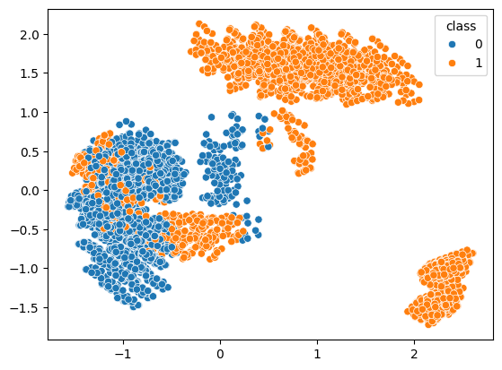

```python
# Use PCA to reduce the data to 2 dimensions, then plot the transformed train set

pca_2d = PCA(n_components=2)
X_train_transformed = pca_2d.fit_transform(X_train)

sns.scatterplot(x=X_train_transformed[:,0], y=X_train_transformed[:,1], hue=y_train.astype(str), hue_order=['0','1']);
```

This visualization is a scatter plot resulting from applying Principal Component Analysis (PCA) with `n_components=2` to the mushroom dataset, reducing its original 22-dimensional feature space into a 2D plane for easier interpretation. The x-axis and y-axis represent the first and second principal components, respectively, which capture the directions of maximum variance in the data. The points are colored based on the class labels: blue dots represent class 0 (likely edible mushrooms, 'e'), and orange dots represent class 1 (likely poisonous mushrooms, 'p').